# Sesión 3. ¿Cuánto vale un jugador elegido?

Promedios, medianas y comparación de grupos con dplyr

Programar con criterio en la era de la IA · Proyecto: pronosticar el éxito en la NFL

2026-10-29

# Antes de empezar: dos tipos de código

Igual que en la sesión 2: al principio del archivo hay dos bloques marcados como **BLOQUE DE FORMATO**. Solo sirven para que el documento HTML se vea bien. **No son parte de la clase**: no hace falta entenderlos ni cambiarlos, y en el HTML no aparecen.

**Todo el código que ves en el HTML es el código que estamos aprendiendo.** Cada línea lleva un comentario (lo que va después de `#`) que dice qué hace.

Los recuadros son los mismos de la sesión 2:

Lo que aprendes de R Qué hace una función nueva y cómo se escribe.

La decisión sobre los datos Qué decidimos sobre los jugadores y por qué. Es la parte de la historia de la NFL.

# Hoy

**Dónde nos quedamos.** En la sesión 2 construimos la base de análisis paso a paso: 3,197 jugadores elegidos entre 2000 y 2014, sin pateadores ni nombres repetidos, y con valor de carrera 0 para los que nunca jugaron. Y dejamos una pregunta sin responder.

**La pregunta de hoy:**

¿Cuánto valor de carrera acumula, en promedio, un jugador elegido? ¿Depende de cuándo y en qué posición fue elegido?

**Lo que aprendes hoy de R:**

| Función | Para qué sirve | Ejemplo |
| --- | --- | --- |
| `mean()` | El promedio | `mean(base$career_av)` |
| `median()` | La mediana: el valor del jugador de en medio | `median(base$career_av)` |
| `summary()` | Mínimo, cuartiles, mediana, promedio y máximo de una vez | `summary(base$career_av)` |
| `hist()` | Un histograma: cuántos jugadores hay en cada tramo de valores | `hist(base$career_av)` |
| `quantile()` | Por debajo de qué valor queda un porcentaje de los jugadores | `quantile(base$career_av, 0.90)` |
| `arrange()` y `desc()` | Ordenar las filas; `desc()` ordena de mayor a menor | `arrange(desc(career_av))` |
| `group_by()` | Partir la tabla en grupos | `group_by(draft_round)` |
| `summarise()` | Calcular algo una vez por grupo | `summarise(mediana = median(career_av))` |
| `n()` | Contar cuántas filas hay en cada grupo | `summarise(jugadores = n())` |
| `ggplot()` y `aes()` | Empezar una gráfica: la tabla y qué columna va en cada eje | `ggplot(base, aes(x = draft_pick, y = career_av))` |
| `geom_point()` y `geom_line()` | Capas de puntos y de líneas | `+ geom_point()` |
| `labs()` | Títulos de la gráfica y de los ejes | `labs(x = "Número de selección")` |

**Plan de la hora:**

| Minutos | Qué hacemos |
| --- | --- |
| 0–5 | La receta de la sesión 2 |
| 5–12 | La respuesta: promedio y mediana |
| 12–22 | La forma del éxito: histograma, cuantiles y los mejores |
| 22–32 | ¿Importa la ronda? `group_by()` y `summarise()` |
| 32–40 | ¿Importa la posición? |
| 40–55 | La gráfica de la sesión 1, paso a paso |
| 55–60 | Lo que aprendimos y cómo es la Tarea 3 |

# 1. La receta

Es la receta de la sesión 2. Ya la conoces: aquí solo la ejecutamos para tener la base lista. Recuerda que el archivo `nfl_data.csv` tiene que estar en la misma carpeta que este documento o dentro de una carpeta llamada `datos`.

```r
# Cargamos el paquete dplyr (filter, mutate, select, group_by... y el símbolo %>%)
library(dplyr)

# Buscamos el archivo: primero en la misma carpeta y, si no está, en la carpeta "datos"
if (file.exists("nfl_data.csv")) {
  ruta_datos <- "nfl_data.csv"
} else {
  ruta_datos <- "datos/nfl_data.csv"
}

# Leemos el archivo: separado por ";", celdas vacías = NA, caracteres especiales en UTF-8
nfl <- read.csv(ruta_datos, sep = ";", na.strings = "", encoding = "UTF-8")

# ---------------------------------------------------------------
# RECETA: de la base cruda (nfl) a la base de análisis (base)
# ---------------------------------------------------------------
tags_repetidos <- nfl$tag[duplicated(nfl$tag)]       # nombre + universidad repetidos

base <- nfl %>%
  rename(forty = X40_yard) %>%                       # nombre más cómodo
  mutate(drafted = as.logical(drafted)) %>%          # "True"/"False" -> TRUE/FALSE
  filter(drafted,                                    # solo elegidos: los únicos con carrera
         year >= 2000, year <= 2014,                 # carreras de al menos diez temporadas
         simple_pos != "ST",                         # sin pateadores ni despejadores
         !(tag %in% tags_repetidos)) %>%             # sin filas con la carrera de otra persona
  mutate(nunca_jugo  = is.na(career_av),             # elegido, pero nunca jugó
         career_av   = ifelse(nunca_jugo, 0, career_av),
         g           = ifelse(nunca_jugo, 0, g),
         pro_bowl    = pro_bowls >= 1,               # fue al menos una vez al Pro Bowl
         speed_score = weight * 200 / forty^4) %>%   # velocidad ajustada por peso
  select(player_id, name, college, year, pos, simple_pos, draft_round, draft_pick, age,
         height, weight, hand_size, arm_length, forty, vert_leap, broad_jump,
         bench_press, shuttle, speed_score,
         career_av, pro_bowls, pro_bowl, g, years_as_primary_starter, nunca_jugo,
         college_games, college_pass_yds, college_pass_td, college_rush_yds,
         college_rec_yds, college_tackles, college_sacks, college_ints)

# Comprobación: deben ser 3,197 jugadores
nrow(base)
```

```
## [1] 3197
```

# 2. La respuesta: promedio y mediana

Lo que aprendes de R `mean()` suma todos los valores y divide entre cuántos son. `median()` ordena a los jugadores de menor a mayor y toma el valor del que queda **en medio**. `summary()` da las dos y algunas cifras más, de una vez.

```r
# El promedio: la suma de todos los valores de carrera dividida entre el número de jugadores
mean(base$career_av)
```

```
## [1] 18.01157
```

```r
# La mediana: si ordenamos a los 3,197 jugadores, el valor del que queda en medio
median(base$career_av)
```

```
## [1] 8
```

El promedio es 18 y la mediana, 8. Son muy distintos. `summary()` ayuda a entender por qué:

```r
# Seis cifras de una vez: mínimo, primer cuartil, mediana, promedio, tercer cuartil y máximo
summary(base$career_av)
```

```
##    Min. 1st Qu.  Median    Mean 3rd Qu.    Max.
##   -4.00    1.00    8.00   18.01   28.00  184.00
```

Cómo se lee:

La decisión sobre los datos ¿Qué cifra le damos al director general? Unos pocos jugadores acumulan muchísimo y **jalan el promedio hacia arriba**: por eso el promedio (18) queda tan lejos de la mediana (8). Si la pregunta es “¿qué carrera tiene un jugador **típico**?”, la respuesta honesta es la mediana: la mitad de los elegidos acumuló 8 puntos o menos.

# 3. La forma del éxito

## Un histograma

Lo que aprendes de R `hist()` dibuja un **histograma**: parte los valores en tramos y dibuja una barra por tramo; la altura es cuántos jugadores caen en él. Es una función de R que no necesita paquetes. Dentro de los paréntesis se le pueden dar opciones separadas por comas.

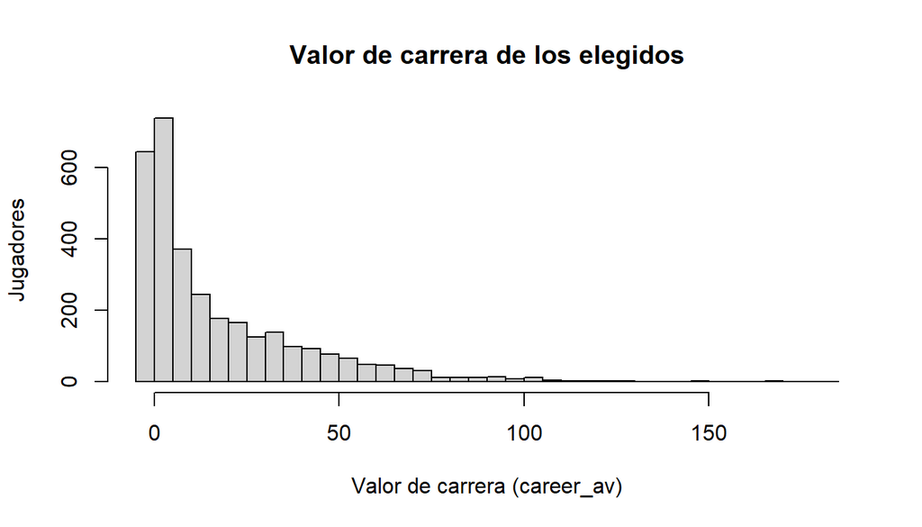

```r
hist(base$career_av,                                 # la columna que queremos ver
     breaks = 40,                                    # en cuántos tramos partimos los valores
     main   = "Valor de carrera de los elegidos",    # título
     xlab   = "Valor de carrera (career_av)",        # nombre del eje horizontal
     ylab   = "Jugadores")                           # nombre del eje vertical
```

Una barra enorme cerca de 0 y una cola larga hacia la derecha. Así se ve una distribución **asimétrica**: muchos jugadores acumulan poco y unos pocos acumulan muchísimo.

¿Cuántos se quedaron exactamente en 0?

```r
# base$career_av == 0 da TRUE para cada jugador con valor 0; sum() cuenta los TRUE
sum(base$career_av == 0)
```

```
## [1] 644
```

```r
# Y como proporción: el promedio de TRUE/FALSE es la proporción de TRUE (sesión 2)
mean(base$career_av == 0)
```

```
## [1] 0.2014388
```

Uno de cada cinco elegidos acumuló **cero**.

## Cuantiles: ¿dónde está el 10% de arriba?

Lo que aprendes de R `quantile(x, 0.90)` da el valor que deja **por debajo** al 90% de los jugadores. La mediana es lo mismo que `quantile(x, 0.50)`.

```r
# ¿Por debajo de qué valor queda el 90% de los jugadores?
quantile(base$career_av, 0.90)
```

```
## 90%
##  51
```

El 90% acumuló 51 puntos o menos. ¿Cuánto del valor total se llevan los que están por encima?

```r
umbral  <- quantile(base$career_av, 0.90)             # el valor que separa al 10% de arriba
mejores <- base %>% filter(career_av >= umbral)       # toma base y quédate con el 10% de arriba

nrow(mejores)                                         # cuántos son
```

```
## [1] 322
```

```r
sum(mejores$career_av) / sum(base$career_av)          # qué parte del valor total acumulan
```

```
## [1] 0.4031398
```

El 10% de los jugadores se lleva el **40%** de todo el valor de carrera.

## Los mejores

Lo que aprendes de R `arrange()` ordena las filas según una columna, de menor a mayor. `arrange(desc(columna))` las ordena de **mayor a menor**. `head(10)` muestra las primeras diez.

```r
base %>%
  arrange(desc(career_av)) %>%                       # y luego ordena de mayor a menor valor
  select(name, year, pos, draft_pick, career_av) %>%  # y luego muestra solo estas columnas
  head(10)                                           # y luego solo las primeras diez filas
```

```
##                   name year pos draft_pick career_av
## 1            Tom Brady 2000  QB        199       184
## 2           Drew Brees 2001  QB         32       167
## 3        Aaron Rodgers 2005  QB         24       166
## 4        Philip Rivers 2004  QB          4       149
## 5            Matt Ryan 2008  QB          3       146
## 6       Russell Wilson 2012  QB         75       139
## 7   Ben Roethlisberger 2004  QB         11       131
## 8  LaDainian Tomlinson 2001  RB          5       129
## 9         Bobby Wagner 2012 OLB         47       127
## 10    Matthew Stafford 2009  QB          1       126
```

La decisión sobre los datos De los diez jugadores con más valor de carrera, **ocho son mariscales de campo** (QB). Es una primera pista de que el valor de carrera no trata igual a todas las posiciones: un buen mariscal juega muchos años y participa en todas las jugadas de ataque. Lo veremos en la sección 5.

# 4. ¿Importa la ronda?

Lo que aprendes de R `group_by()` parte la tabla en **grupos**: uno por cada valor de la columna que le demos. `summarise()` calcula lo que le pidamos **una vez por grupo** y devuelve una tabla con una fila por grupo. Dentro de `summarise()`, `n()` cuenta cuántos jugadores hay en cada grupo.

Se lee así: “toma `base`, y luego agrúpala por ronda, y luego, para cada ronda, calcula…”.

```r
base %>%
  group_by(draft_round) %>%                  # y luego un grupo por cada ronda (1 a 7)
  summarise(jugadores     = n(),             # cuántos jugadores hay en la ronda
            promedio      = mean(career_av), # su valor de carrera promedio
            mediana       = median(career_av),   # su mediana
            nunca_jugaron = mean(nunca_jugo))    # proporción que nunca jugó
```

```
## # A tibble: 7 × 5
##   draft_round jugadores promedio mediana nunca_jugaron
##         <dbl>     <int>    <dbl>   <dbl>         <dbl>
## 1           1       397    45.0       40        0
## 2           2       423    28.9       24        0.0118
## 3           3       465    18.9       11        0.0258
## 4           4       479    14.8        8        0.0543
## 5           5       455     9.91       3        0.127
## 6           6       450     7.92       3        0.191
## 7           7       528     6.67       1        0.231
```

Cada nombre a la izquierda del `=` (`jugadores`, `promedio`…) es el nombre que tendrá la columna en el resultado: lo eliges tú.

La decisión sobre los datos Los equipos no eligen a ciegas. La mediana cae de **40** en la primera ronda a **1** en la séptima, y casi uno de cada cuatro elegidos en la séptima ronda nunca jugó. El orden del draft dice mucho del futuro de un jugador.

Pero dice mucho **en promedio**: en cada ronda hay de todo. Tom Brady fue elegido en la sexta ronda.

# 5. ¿Importa la posición?

El mismo código, agrupando por posición. Al final añadimos `arrange()` para ordenar la tabla de mayor a menor mediana:

```r
base %>%
  group_by(simple_pos) %>%                   # y luego un grupo por cada posición
  summarise(jugadores = n(),                 # cuántos jugadores hay
            promedio  = mean(career_av),     # su promedio
            mediana   = median(career_av)) %>%   # su mediana
  arrange(desc(mediana))                     # y luego ordena de mayor a menor mediana
```

```
## # A tibble: 8 × 4
##   simple_pos jugadores promedio mediana
##   <chr>          <int>    <dbl>   <dbl>
## 1 OL               568     22.9    14
## 2 DL               534     19.8    11
## 3 LB               385     19.1     9
## 4 DB               659     14.9     8
## 5 RB               296     14.8     5.5
## 6 WR               405     15.8     5
## 7 QB               170     23.5     4
## 8 TE               180     11.2     4
```

Mira la fila de los mariscales (`QB`) y compárala con las demás. Según mires el promedio o la mediana, los mariscales están entre los mejores o entre los peores.

La decisión sobre los datos ¿Cuál de las dos medidas hay que mirar para comparar posiciones? No hay una respuesta automática: depende de la pregunta que quieras responder. **Esa decisión es la Tarea 3.**

# 6. La gráfica de la sesión 1, paso a paso

En la sesión 1 vimos una gráfica sin su código: cada punto era un jugador elegido, con su número de selección y su valor de carrera, y una línea naranja marcaba el promedio. Ya tienes todo lo necesario para hacerla tú.

Usamos nuestra base (elegidos de 2000 a 2014). La de la sesión 1 empezaba en 1987: por eso aquí hay menos puntos y no aparece Peyton Manning, que fue elegido en 1998.

Lo que aprendes de R Las gráficas se hacen con el paquete **ggplot2**, que instalaste en la sesión 1. Una gráfica de ggplot2 se arma **por capas**:

- `ggplot(tabla, aes(x = ..., y = ...))` dice qué tabla usar y qué columna va en cada eje. `aes()` viene de *aesthetics* (estética): qué columna se ve dónde.
- `geom_point()` agrega una capa de puntos; `geom_line()`, una de líneas.
- Las capas se suman con `+`, **no** con `%>%`. Es el error más común.

## Paso 1: los puntos

```r
base
```

[output not shown]

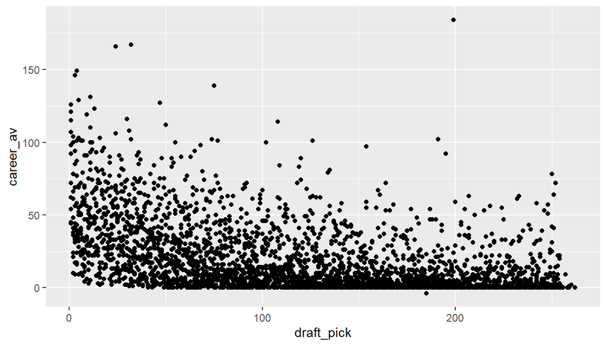

```r
library(ggplot2)   # cargamos el paquete de gráficas

ggplot(base, aes(x = draft_pick, y = career_av)) +   # la tabla y qué va en cada eje
  geom_point()                                       # y encima, una capa de puntos
```

Cada punto es un jugador. Son tantos que se tapan unos a otros: no se ve dónde se concentran ni hacia dónde va el valor de carrera.

## Paso 2: la tabla del promedio

Para dibujar la línea necesitamos otra tabla con el promedio. Si calculáramos un promedio por cada número de selección, cada uno saldría de 15 jugadores como mucho (uno por año) y la línea saltaría mucho. Por eso juntamos las selecciones de 8 en 8 y calculamos el promedio de cada bloque. Es `group_by()` + `summarise()`, lo mismo de la sección 4.

Lo que aprendes de R `ceiling()` redondea hacia arriba. `ceiling(draft_pick / 8)` da 1 para las selecciones 1 a 8, 2 para las 9 a 16, 3 para las 17 a 24, y así.

```r
promedios <- base %>%
  mutate(bloque = ceiling(draft_pick / 8)) %>%   # bloques de 8: 1-8, 9-16, 17-24...
  group_by(bloque) %>%                           # y luego un grupo por bloque
  summarise(draft_pick = mean(draft_pick),       # selección promedio del bloque
            career_av  = mean(career_av),        # valor de carrera promedio
            jugadores  = n()) %>%                # jugadores en el bloque
  filter(jugadores >= 10)                        # el último bloque tiene solo 6: fuera

head(promedios)    # las primeras filas de la tabla nueva
```

```
## # A tibble: 6 × 4
##   bloque draft_pick career_av jugadores
##    <dbl>      <dbl>     <dbl>     <int>
## 1      1       4.61      54.3       102
## 2      2      12.4       47.2        95
## 3      3      20.6       41.8        95
## 4      4      28.5       37.8       108
## 5      5      36.4       34.3       103
## 6      6      44.5       29.0       111
```

A las columnas les pusimos a propósito los mismos nombres que tienen en `base` (`draft_pick` y `career_av`): así la línea puede usar los mismos ejes que los puntos.

## Paso 3: la gráfica completa

Sobre los puntos del paso 1 agregamos la línea, marcamos a Tom Brady y ponemos títulos:

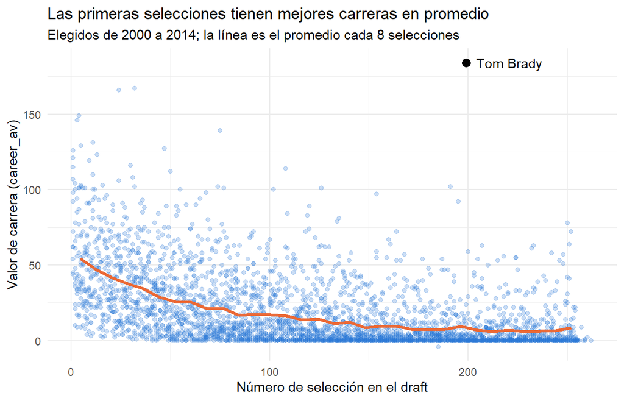

```r
brady <- base %>% filter(name == "Tom Brady")   # una tabla con una sola fila: Tom Brady

ggplot(base, aes(x = draft_pick, y = career_av)) +   # la tabla y los ejes, como antes
  # Capa 1: los puntos, azules y transparentes
  geom_point(color = "#2a78d6", alpha = 0.25) +
  # Capa 2: la línea del promedio, con la tabla promedios
  geom_line(data = promedios, color = "#eb6834", linewidth = 1.2) +
  # Capa 3: Tom Brady, con un punto más grande y su nombre a la derecha
  geom_point(data = brady, size = 3) +
  geom_text(data = brady, aes(label = name), hjust = -0.15) +
  # Títulos de la gráfica y de los ejes
  labs(title = "Las primeras selecciones tienen mejores carreras en promedio",
       subtitle = "Elegidos de 2000 a 2014; la línea es el promedio cada 8 selecciones",
       x = "Número de selección en el draft",
       y = "Valor de carrera (career_av)") +
  # Un estilo con fondo limpio
  theme_minimal()
```

Lo que aprendes de R

- `color = "#2a78d6"`: un color fijo, escrito como código de color (azul). Va **fuera** de `aes()` porque no depende de ninguna columna.
- `alpha = 0.25`: transparencia, de 0 (invisible) a 1 (sólido). Donde se juntan muchos puntos, el color se ve más oscuro.
- `data = promedios`: esa capa usa **otra tabla**. Los ejes `x` e `y` los toma de lo que dijimos en `ggplot()`: por eso las columnas tienen que llamarse igual.
- `aes(label = name)`: el texto de la etiqueta sale de la columna `name`. Va **dentro** de `aes()` porque sí depende de una columna.
- `labs()` pone los títulos y `theme_minimal()` cambia el estilo del fondo.

La decisión sobre los datos La línea cae con fuerza en las primeras selecciones y después baja cada vez más despacio: elegir entre los primeros importa mucho. Pero alrededor de la línea hay de todo, y el punto más alto del archivo está en la selección 199.

Recuerda lo de hoy: la línea es un **promedio**, y a los promedios los jalan las estrellas. Pruébalo: en el paso 2 cambia `mean(career_av)` por `median(career_av)`, ejecuta de nuevo el paso 3 y mira qué le pasa a la línea.

# Lo que aprendimos hoy

| De R | De los datos |
| --- | --- |
| `mean()`, `median()` y `summary()` para resumir una columna | El promedio (18) y la mediana (8) cuentan historias distintas |
| `hist()` para ver la forma de una columna | El éxito es muy desigual: uno de cada cinco se queda en 0 |
| `quantile()` para ubicar a los de arriba | El 10% de arriba se lleva el 40% del valor |
| `arrange()` y `desc()` para ordenar | Ocho de los diez mejores son mariscales |
| `group_by()` + `summarise()` + `n()` para comparar grupos | La mediana cae de 40 en la primera ronda a 1 en la séptima |
| `ggplot()` + capas (`geom_point()`, `geom_line()`, `labs()`) para graficar | El promedio cae con el número de selección, pero alrededor de la línea hay de todo |

# Tarea 3 (después de clase): ¿elegimos mariscales?

**Tiempo estimado:** 20 minutos.

**Qué entregas:** tu archivo `sesion3_trabajo.Rmd` (una copia de este documento con tus respuestas) en la carpeta `sesion-3/` de tu repositorio de GitHub.

**Qué se valora:** que tomes una **decisión** y la **fundamentes** con tus propios números. No hay una respuesta única correcta: hay decisiones bien fundamentadas y decisiones mal fundamentadas.

El analista jefe del equipo te escribe:

> “Revisé el valor de carrera por posición: los mariscales tienen el **promedio más alto** de todos. Propongo que el equipo use sus primeras selecciones del próximo draft en mariscales.”

Tu trabajo es decidir si le haces caso y explicar por qué.

## Cómo se fundamenta una decisión

Una decisión bien fundamentada tiene cuatro partes:

1. **Decisión:** qué harías, en una frase.
2. **Evidencia:** los números que la respaldan, calculados por ti.
3. **Razonamiento:** por qué esos números llevan a esa decisión.
4. **Límite:** qué no sabes, o qué tendría que pasar para que cambiaras de opinión.

**Un ejemplo con lo de hoy** (no es la respuesta de la tarea):

- *Decisión:* para describir al jugador típico, le daría al director la mediana, no el promedio.
- *Evidencia:* la mediana es 8 y el promedio, 18; uno de cada cinco elegidos acumuló 0 y el 10% de arriba se lleva el 40% del valor.
- *Razonamiento:* unos pocos jugadores con valores enormes suben el promedio; la mediana no se mueve con ellos, así que describe mejor lo que le pasa a la mayoría.
- *Límite:* si al director le interesa el valor **total** que produce un draft, y no el del jugador típico, el promedio sí sirve.

## Paso 1. Anticipa

Antes de calcular nada: ¿crees que el analista tiene razón?Yo creo que tiene la razon ya que las estrellas mas grandes de el futbol americano son los QBs, y por lo tanto los QB van a ser los mas valiosos.

*Mi respuesta:*

## Paso 2. Comprueba lo que dice el analista

Quita los signos de gato (`#`) y ejecuta (atajo: selecciona las líneas y pulsa `Ctrl + Shift + C`; en Mac, `Cmd + Shift + C`). ¿Es cierto que los mariscales tienen el promedio más alto?Si, los QB tienen el promedio mas alto

```r
 base %>%
   group_by(simple_pos) %>%
   summarise(promedio = mean(career_av)) %>%
   arrange(desc(promedio))
```

```
## # A tibble: 8 × 2
##   simple_pos promedio
##   <chr>         <dbl>
## 1 QB             23.5
## 2 OL             22.9
## 3 DL             19.8
## 4 LB             19.1
## 5 WR             15.8
## 6 DB             14.9
## 7 RB             14.8
## 8 TE             11.2
```

## Paso 3. Busca más evidencia

Primero, guarda solo a los mariscales en un objeto (quita los `#`):

```r
 qb <- base %>% filter(simple_pos == "QB")
 nrow(qb)
```

```
## [1] 170
```

**a) ¿Qué pasa con la mediana?** Compara la mediana de los mariscales con la de las demás posiciones. Pista: el código de la sección 5. Cuando se usa la mediana en vez de la media, los QB van de la posicion mas valiosa a la segunda menos valiosa

```r
 base %>%
   group_by(simple_pos) %>%
   summarise(mediana = median(career_av)) %>%
   arrange(desc(mediana))
```

```
## # A tibble: 8 × 2
##   simple_pos mediana
##   <chr>        <dbl>
## 1 OL            14
## 2 DL            11
## 3 LB             9
## 4 DB             8
## 5 RB             5.5
## 6 WR             5
## 7 QB             4
## 8 TE             4
```

**b) ¿Cuántos mariscales se quedaron en 0?** Pista: `sum(qb$career_av == 0)`. 56 QB se quedaron en cero

```r
sum(qb$career_av==0)
```

```
## [1] 56
```

**c) ¿Importa en qué ronda se elige al mariscal?** Separa a los mariscales elegidos en la primera ronda de los demás y compara sus medianas. Completa los `___` y quita los `#`: Los QB elegidos en la primera ronda tienen una mediana 44 veces mayor que el resto de los QB, asi que si importa la ronda en la que son elegidos.

```r
 qb_primera <- qb %>% filter(draft_round == 1)
 qb_resto   <- qb %>% filter(draft_round > 1)
 median(qb_primera$career_av)
```

```
## [1] 44
```

```r
 median(qb_resto$career_av)
```

```
## [1] 1
```

```r
 base %>% group_by(draft_round) %>% summarise(mediana=median(career_av))
```

```
## # A tibble: 7 × 2
##   draft_round mediana
##         <dbl>   <dbl>
## 1           1      40
## 2           2      24
## 3           3      11
## 4           4       8
## 5           5       3
## 6           6       3
## 7           7       1
```

##Los QB son la posicion de primer draft mas valioso?

```r
base %>% filter(draft_round==1) %>% group_by(simple_pos) %>% summarise(mediana=median(career_av)) %>% arrange(desc(mediana))
```

```
## # A tibble: 8 × 2
##   simple_pos mediana
##   <chr>        <dbl>
## 1 LB            55
## 2 OL            46
## 3 QB            44
## 4 WR            40
## 5 RB            39
## 6 DL            36.5
## 7 DB            35
## 8 TE            35
```

##Los QB tienen el mayor valor en la primera ronda comparada con las otras?

```r
Rond1 <- base %>% filter(draft_round==1) %>% group_by(simple_pos) %>% summarise(mediana=median(career_av))
RondO <- base %>% filter(draft_round>1) %>% group_by(simple_pos) %>% summarise(mediana=median(career_av))
ValorComparativo <- Rond1 %>% inner_join(RondO, by="simple_pos") %>% mutate(Comparar=Rond1$mediana/RondO$mediana) %>% arrange(desc(Comparar))
ValorComparativo
```

```
## # A tibble: 8 × 4
##   simple_pos mediana.x mediana.y Comparar
##   <chr>          <dbl>     <dbl>    <dbl>
## 1 QB              44           1    44
## 2 TE              35           3    11.7
## 3 WR              40           4    10
## 4 RB              39           4     9.75
## 5 LB              55           7     7.86
## 6 DB              35           6     5.83
## 7 DL              36.5         7     5.21
## 8 OL              46          11     4.18
```

## Paso 4. Decide y fundamenta

Responde al analista con las cuatro partes. Usa **tus** números de los pasos 2 y 3.

**Para entregar:** en RStudio, botón **Knit** para comprobar que todo se ejecuta. Después, en GitHub, entra a tu repositorio, abre la carpeta `sesion-3`, **Add file > Upload files**, sube `sesion3_trabajo.Rmd` y escribe un mensaje como *Agregar trabajo de la sesión 3*.

| Criterio | Qué se revisa |
| --- | --- |
| Evidencia calculada | Los pasos 2 y 3 están completos y se ejecutan |
| Decisión | Es clara y responde a la propuesta del analista |
| Fundamento | La evidencia son números tuyos y el razonamiento explica por qué llevan a tu decisión |
| Límite | Reconoces qué no sabes o qué te haría cambiar de opinión |